# Report 13

### XGBoost

```r
dtrain = xgb.DMatrix(data = as.matrix(x.train), label = y.train)
dtest = xgb.DMatrix(data = as.matrix(x.test), label = y.test)

params = list(objective = "reg:squarederror", eval_metric = "rmse",
    eta = 0.05, max_depth = 2, subsample = 0.6, colsample_bytree = 0.6,
    min_child_weight = 5, lambda = 5, alpha = 2)

cv = xgb.cv(params = params, data = dtrain, nrounds = 500, nfold = 10,
    early_stopping_rounds = 20, verbose = 0)

best_nrounds = cv$best_iteration

xgb_fit = xgb.train(params = params, data = dtrain, nrounds = best_nrounds,
    verbose = 0)

pred_mean = predict(xgb_fit, as.matrix(x.test))

xgb_predictions = data.frame(estimate = pred_mean, observed = y.test)

pred_fun_xgb <- function(object, newdata) {
    predict(object, as.matrix(newdata))
}
```

XGBoost has different important metrics. Let’s check them out (gain is importance).

```r
knitr::kable(xgb.importance(model = xgb_fit))
```

| Feature | Gain | Cover | Frequency |
| --- | --- | --- | --- |
| n_hsa | 0.4043269 | 0.2313285 | 0.2101266 |
| area_ratio | 0.2178145 | 0.1411324 | 0.1493671 |
| unemployment_diff | 0.1816557 | 0.2337960 | 0.2101266 |
| poverty_diff | 0.0549404 | 0.0456929 | 0.0481013 |
| pct_urban | 0.0462096 | 0.1244768 | 0.1291139 |
| pop_ratio | 0.0409503 | 0.0640229 | 0.0683544 |
| education_diff | 0.0249896 | 0.0818683 | 0.0936709 |
| density_ratio | 0.0223793 | 0.0453404 | 0.0556962 |
| income_diff | 0.0067337 | 0.0323419 | 0.0354430 |

```r
hsa.pdp.xgb = pdp::partial(object = xgb_fit, pred.var = "n_hsa",
    pred.fun = pred_fun_xgb, train = x.train, plot = FALSE)
unemploy.pdp.xgb = pdp::partial(object = xgb_fit, pred.var = "unemployment_diff",
    pred.fun = pred_fun_xgb, train = x.train, plot = FALSE)
```

```r
hsa.xgb = ggplot(hsa.pdp.xgb, aes(n_hsa, yhat)) + geom_line(aes(group = yhat.id),
    alpha = 0.2) + stat_summary(fun = mean, geom = "line", col = "red",
    size = 1) + theme_minimal() + labs(title = "ICE plot for n_hsa (XGBoost)",
    x = "n_hsa", y = "Predicted response") + scale_y_continuous(limits = c(-0.25,
    1.25), breaks = seq(-0.25, 1.25, by = 0.25))

unemploy.xgb = ggplot(unemploy.pdp.xgb, aes(unemployment_diff,
    yhat)) + geom_line(aes(group = yhat.id), alpha = 0.2) + stat_summary(fun = mean,
    geom = "line", col = "red", size = 1) + theme_minimal() +
    labs(title = "ICE plot for unemployment_diff (XGBoost)",
        x = "unemployment_diff", y = "Predicted response") +
    scale_y_continuous(limits = c(-0.25, 1.25), breaks = seq(-0.25,
        1.25, by = 0.25))
```

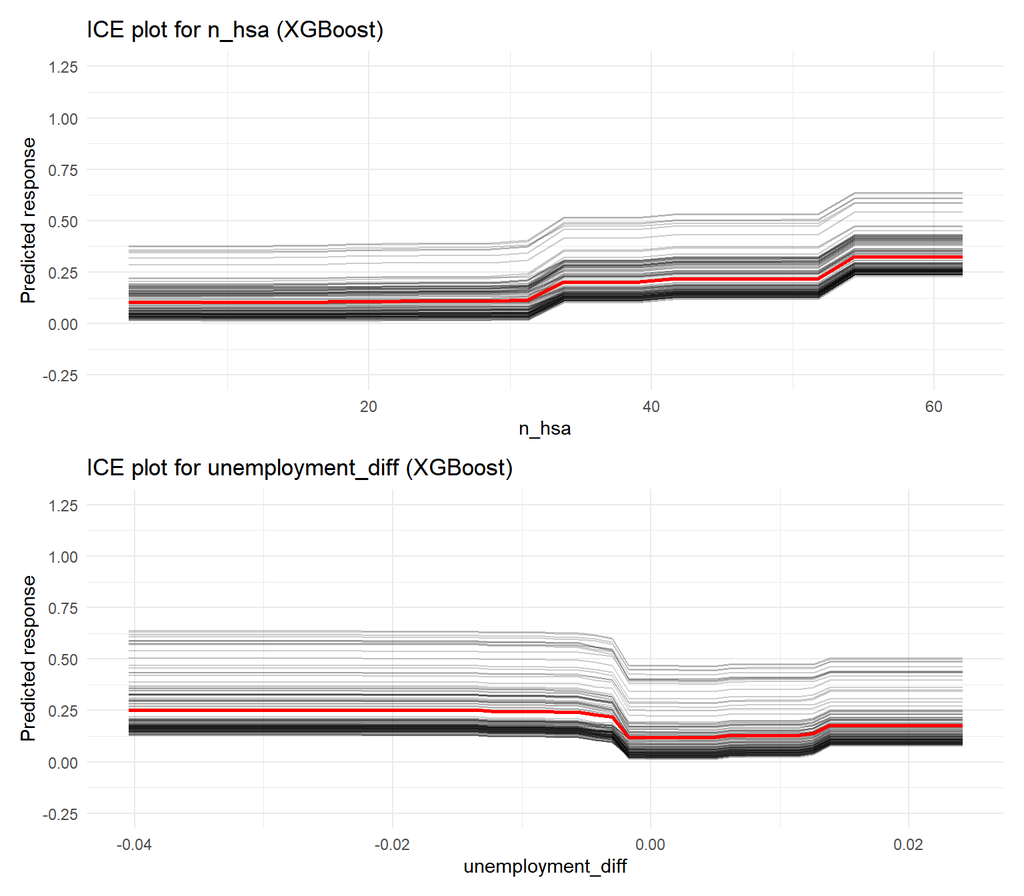

```r
hsa.xgb/unemploy.xgb
```

As we can see, the XGBoost model has a clear effect for n_hsa and unemployment_diff, however, these effects are global across all rows and therefore the PDP line represents the correlation quite well, with a dropoff or pickup at certain values of the variable that change the predicted response. Also, there are no very clear outliers in these figures like there was in BART, so no need to address that with the outlier-free versions.

# Why is $R^2$ so low?

```r
# y.train.scaled = scale(y.train) center =
# attr(y.train.scaled, 'scaled:center') scale =
# attr(y.train.scaled, 'scaled:scale')

bart_fit = bart(x.train = x.train, y.train = y.train, verbose = FALSE,
    keeptrees = TRUE)

pred = predict(bart_fit, newdata = x.test)
bart_predictions = as.data.frame(t(apply(pred, 2, quantile, probs = c(0.025,
    0.975))))
colnames(bart_predictions) = c("ci_low", "ci_high")

bart_predictions$estimate = apply(pred, 2, mean)
# bart_predictions$estimate = bart_predictions$estimate *
# scale + center

bart_predictions$observed = y.test

var(bart_predictions$estimate)
```

```
## [1] 0.01621831
```

```r
var(y.train)
```

```
## [1] 0.07576043
```

```r
var(y.test)
```

```
## [1] 0.09730513
```

```r
R2_bart = 1 - sum((bart_predictions$observed - bart_predictions$estimate)^2)/sum((bart_predictions$observed -
    mean(bart_predictions$observed))^2)
R2_bart
```

```
## [1] 0.1834688
```

# Ensemble of both models

## Weighted average

Let’s try a convex combination of weights and see what works the best!

```r
weights = seq(0, 1.5, by = 0.1)  # BART weights

results = data.frame(bart_weight = numeric(), xgb_weight = numeric(),
    R2 = numeric(), RMSE = numeric())

for (w1 in weights) {
    w2 = 1 - w1

    ensemble = w1 * bart_predictions$estimate + w2 * xgb_predictions$estimate

    R2_val = 1 - sum((y.test - ensemble)^2)/sum((y.test - mean(y.test))^2)

    RMSE_val = sqrt(mean((y.test - ensemble)^2))

    results = rbind(results, data.frame(bart_weight = w1, xgb_weight = w2,
        R2 = R2_val, RMSE = RMSE_val))
}

knitr::kable(results, digits = 4, title = "Weighted average ensemble metrics")
```

| bart_weight | xgb_weight | R2 | RMSE |
| --- | --- | --- | --- |
| 0.0 | 1.0 | 0.1398 | 0.2865 |
| 0.1 | 0.9 | 0.1468 | 0.2853 |
| 0.2 | 0.8 | 0.1532 | 0.2843 |
| 0.3 | 0.7 | 0.1591 | 0.2833 |
| 0.4 | 0.6 | 0.1643 | 0.2824 |
| 0.5 | 0.5 | 0.1690 | 0.2816 |
| 0.6 | 0.4 | 0.1730 | 0.2809 |
| 0.7 | 0.3 | 0.1765 | 0.2803 |
| 0.8 | 0.2 | 0.1794 | 0.2798 |
| 0.9 | 0.1 | 0.1817 | 0.2794 |
| 1.0 | 0.0 | 0.1835 | 0.2792 |
| 1.1 | -0.1 | 0.1846 | 0.2790 |
| 1.2 | -0.2 | 0.1852 | 0.2789 |
| 1.3 | -0.3 | 0.1851 | 0.2789 |
| 1.4 | -0.4 | 0.1845 | 0.2790 |
| 1.5 | -0.5 | 0.1833 | 0.2792 |

```r
w1 = 1.3
w2 = -0.3

ensemble_predictions = data.frame(estimate = w1 * bart_predictions$estimate +
    w2 * xgb_predictions$estimate, observed = y.test)

R2_ensemble = 1 - sum((y.test - ensemble_predictions$estimate)^2)/sum((y.test -
    mean(y.test))^2)
RMSE_ensemble = sqrt(mean((y.test - ensemble_predictions$estimate)^2))
```

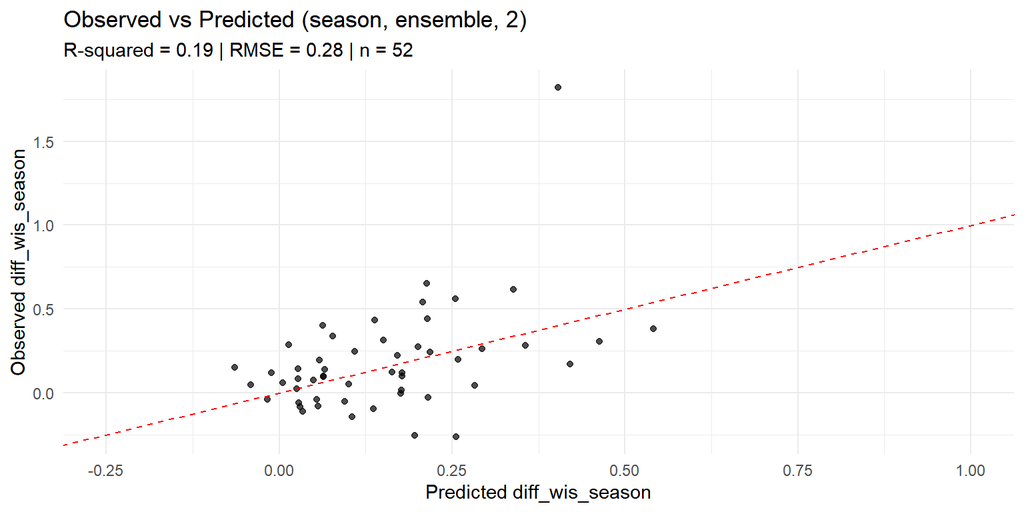

```r
ggplot(ensemble_predictions, aes(x = estimate, y = observed)) +
    geom_point(alpha = 0.7) + geom_abline(slope = 1, intercept = 0,
    linetype = "dashed", color = "red") + labs(x = "Predicted diff_wis_season",
    y = "Observed diff_wis_season", title = "Observed vs Predicted (season, ensemble, 2)",
    subtitle = sprintf("R-squared = %.2f | RMSE = %.2f | n = %.0f",
        R2_ensemble, RMSE_ensemble, nrow(x.test))) + theme_minimal() +
    scale_x_continuous(breaks = seq(-1, 2, by = 0.25)) + coord_cartesian(xlim = c(-0.25,
    1))
```

Wow, this actually looks kinda decent and improves on the BART.

## Stacked

We can also try using linear regression to fit this for us.

```r
K = 5
folds = createFolds(y.train, k = K, returnTrain = FALSE)

bart_pred_train = rep(NA, length(y.train))
xgb_pred_train = rep(NA, length(y.train))

for (i in 1:K) {
    test_idx = folds[[i]]
    train_idx = setdiff(1:length(y.train), test_idx)

    x_tr = x.train[train_idx, ]
    y_tr = y.train[train_idx]

    x_te = x.train[test_idx, ]

    bart_fit_cv = bart(x_tr, y_tr, ntree = 200, verbose = FALSE,
        keeptrees = TRUE)
    bart_pred_train[test_idx] = colMeans(predict(bart_fit_cv,
        x_te))

    dtr = xgb.DMatrix(data = as.matrix(x_tr), label = y_tr)
    xgb_fit_cv = xgboost(data = dtr, nrounds = 200, verbose = 0)
    xgb_pred_train[test_idx] = predict(xgb_fit_cv, as.matrix(x_te))
}
```

```r
meta_train = data.frame(bart_pred = bart_pred_train, xgb_pred = xgb_pred_train,
    y = y.train)

meta_model = lm(y ~ bart_pred + xgb_pred, data = meta_train)
coef(meta_model)
```

```
## (Intercept)   bart_pred    xgb_pred
##  0.01327917  0.88867384  0.04394978
```

```r
meta_test = data.frame(bart_pred = bart_predictions$estimate,
    xgb_pred = xgb_predictions$estimate)

ensemble_pred = predict(meta_model, newdata = meta_test)

ensemble_predictions_smart = data.frame(estimate = ensemble_pred,
    observed = y.test)

R2_ensemble_smart = 1 - sum((y.test - ensemble_predictions_smart$estimate)^2)/sum((y.test -
    mean(y.test))^2)
RMSE_ensemble_smart = sqrt(mean((y.test - ensemble_predictions_smart$estimate)^2))
```

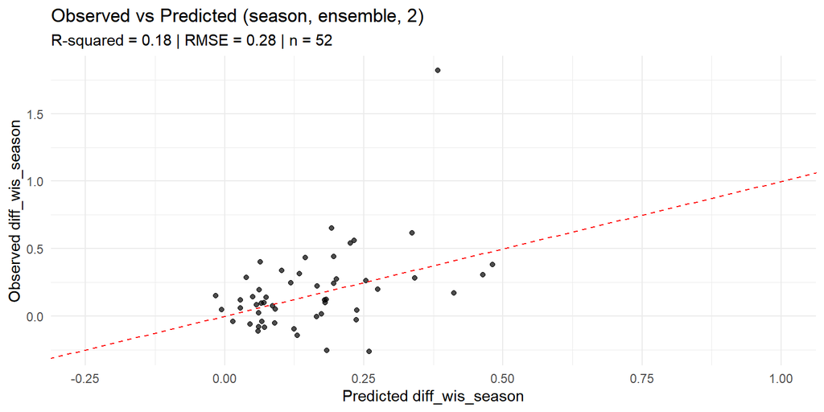

```r
ggplot(ensemble_predictions_smart, aes(x = estimate, y = observed)) +
    geom_point(alpha = 0.7) + geom_abline(slope = 1, intercept = 0,
    linetype = "dashed", color = "red") + labs(x = "Predicted diff_wis_season",
    y = "Observed diff_wis_season", title = "Observed vs Predicted (season, ensemble, 2)",
    subtitle = sprintf("R-squared = %.2f | RMSE = %.2f | n = %.0f",
        R2_ensemble_smart, RMSE_ensemble_smart, nrow(x.test))) +
    theme_minimal() + scale_x_continuous(breaks = seq(-1, 2,
    by = 0.25)) + coord_cartesian(xlim = c(-0.25, 1))
```

We can check how the ensemble is doing worse because both of these models are correlated with each other and therefore we are just amplifying noise right now.

```r
cor(bart_predictions$estimate, xgb_predictions$estimate)
```

```
## [1] 0.9094812
```

Yikes, that’s bad. Maybe next time or over break, I can investigate possibly trying to purposely overfit one of these models so that we can balance them out a bit.

# Conclusion